# RAssignment

2024-03-07

Data Inspection

Download the files and into the git folder created and confirm the downloaded file by checking the content.

```r
file.show("snp_position.txt")
file.show("fang_et_al_genotypes.txt")
```

Assign the files to objects to inspect the data

```r
genotypes <- read.table("fang_et_al_genotypes.txt", header = T,sep = "\t", stringsAsFactors = T)
snps <- read.table("snp_position.txt", header = T, sep = "\t", stringsAsFactors = F)
```

Inspect the data in the files

```r
View(genotypes)
dim(genotypes)
```

```
## [1] 2782  986
```

```r
ncol(genotypes)
```

```
## [1] 986
```

```r
nrow(genotypes)
```

```
## [1] 2782
```

```r
class(genotypes)
```

```
## [1] "data.frame"
```

```r
object.size (genotypes)
```

```
## 12163888 bytes
```

```r
View(snps)
dim(snps)
```

```
## [1] 983  15
```

```r
ncol(snps)
```

```
## [1] 15
```

```r
nrow(snps)
```

```
## [1] 983
```

```r
class(snps)
```

```
## [1] "data.frame"
```

```r
object.size(snps)
```

```
## 327392 bytes
```

By inspecting the data in file fang_et_al_genotypes.txt(genotypes), I learned that the

- file has 2782 rows(objects) and 986 columns(variables)
- file size is 12163888 bytes
- file can be inspected as data frames

By inspecting the data in file snp_position.txt(snps), I learned that the

- file has 983 rows (objects) and 15 columns(variables)
- file size is 327392 bytes
- file can be inspected as data frames

Data Processing

Load the required packages

```r
library(plyr)
library(dplyr)
```

```r
library(ggplot2)
library(tidyverse)
library(tibble)
```

Extracted the groups for maize and teosinte and confirmed

```r
maizegenotypes <- filter(genotypes, Group %in% c("ZMMIL","ZMMLR","ZMMMR"))
teosintegenotypes <- filter(genotypes, Group %in% c("ZMPBA","ZMPIL","ZMPJA"))

summary(as.factor(maizegenotypes$Group))
```

```
## TRIPS ZDIPL ZLUXR ZMHUE ZMMIL ZMMLR ZMMMR ZMPBA ZMPIL ZMPJA ZMXCH ZMXCP ZMXIL
##     0     0     0     0   290  1256    27     0     0     0     0     0     0
## ZMXNO ZMXNT ZPERR
##     0     0     0
```

```r
View(maizegenotypes)
summary(as.factor(teosintegenotypes$Group))
```

```
## TRIPS ZDIPL ZLUXR ZMHUE ZMMIL ZMMLR ZMMMR ZMPBA ZMPIL ZMPJA ZMXCH ZMXCP ZMXIL
##     0     0     0     0     0     0     0   900    41    34     0     0     0
## ZMXNO ZMXNT ZPERR
##     0     0     0
```

```r
View(teosintegenotypes)
```

Removed the first three columns of maize and teosinte genotypes files to prepare them for transpose

```r
modifiedmaizegenotypes <- maizegenotypes[-(1:3)]
modifiedteosintegenotypes <- teosintegenotypes[-(1:3)]


View(modifiedmaizegenotypes)
View(modifiedteosintegenotypes)
```

Transposed the files to prepare them for merging

```r
transposedmaize <- as.data.frame(t(modifiedmaizegenotypes))
transposedteosinte <- as.data.frame(t(modifiedteosintegenotypes))


View(transposedmaize)
class(transposedmaize)
```

```
## [1] "data.frame"
```

```r
dim(transposedmaize)
```

```
## [1]  983 1573
```

```r
View(transposedteosinte)
class(transposedteosinte)
```

```
## [1] "data.frame"
```

```r
dim(transposedteosinte)
```

```
## [1] 983 975
```

Modified the snps by removing unwanted columns

```r
modifiedsnps <- snps[-(2)]
View(modifiedsnps)
class(modifiedsnps)
```

```
## [1] "data.frame"
```

Combined the modified snps and transposed maize and teosinte

```r
mergedmaize <- cbind(modifiedsnps, transposedmaize)
mergedteosinte <- cbind(modifiedsnps, transposedteosinte)

View(mergedmaize)
class(mergedmaize)
```

```
## [1] "data.frame"
```

```r
dim(mergedmaize)
```

```
## [1]  983 1587
```

```r
View(mergedteosinte)
class(mergedteosinte)
```

```
## [1] "data.frame"
```

```r
dim(mergedteosinte)
```

```
## [1] 983 989
```

Create maize and teosinte files with modified missing values

```r
decreasemaize <- as.data.frame(apply(mergedmaize,2, function(x) gsub("\\?/\\?", "-/-", x)))
decreaseteosinte <- as.data.frame(apply(mergedteosinte,2, function(x) gsub("\\?/\\?", "-/-", x)))

View(decreasemaize)
View(decreaseteosinte)
```

```r
dir.create('./incmaize')
dir.create('./decmaize')
dir.create('./incteosinte')
dir.create('./decteosinte')
```

Create files with increasing order of position for each chromosome both in maize and teosinte

```r
lapply(unique(mergedmaize$Chromosome), function(chrom_num) {
  maizechrom <- mergedmaize %>% filter(Chromosome == chrom_num) %>% arrange(Position)
  write.table(maizechrom,sep = "\t", file = paste("./incmaize/maizeinc", chrom_num, sep = "_"), quote = FALSE)
})
```

```r
lapply(unique(mergedteosinte$Chromosome), function(chrom_num) {
  teosintechrom <- mergedteosinte %>% filter(Chromosome == chrom_num) %>% arrange(Position)
  write.table(teosintechrom,sep = "\t", file = paste("./incteosinte/teosinteinc", chrom_num, sep = "_"), quote = FALSE)
})
```

```r
lapply(unique(decreasemaize$Chromosome), function(chrom_num) {
  maizechrom <- decreasemaize %>% filter(Chromosome == chrom_num) %>% arrange(Position)
  write.table(maizechrom,sep = "\t", file = paste("./decmaize/maizedec", chrom_num, sep = "_"), quote = FALSE)
})
```

```r
lapply(unique(decreaseteosinte$Chromosome), function(chrom_num) {
  teosintechrom <- decreaseteosinte %>% filter(Chromosome == chrom_num) %>% arrange(Position)
  write.table(teosintechrom,sep = "\t", file = paste("./decteosinte/teosintedec", chrom_num, sep = "_"), quote = FALSE)
})
```

Data Visualization

Prepared files for visualization

```r
modifiedgenotypes <- genotypes[-(1:3)]
transposedgenotypes <- as.data.frame(t(modifiedgenotypes))
modifiedsnps <- snps[-(2)]
mergedfiles <- cbind(modifiedsnps, transposedgenotypes)
cmergedfiles <- mergedfiles[-(1)]
View(cmergedfiles)
class(cmergedfiles)
```

```
## [1] "data.frame"
```

The snps counts per chromosome visualization

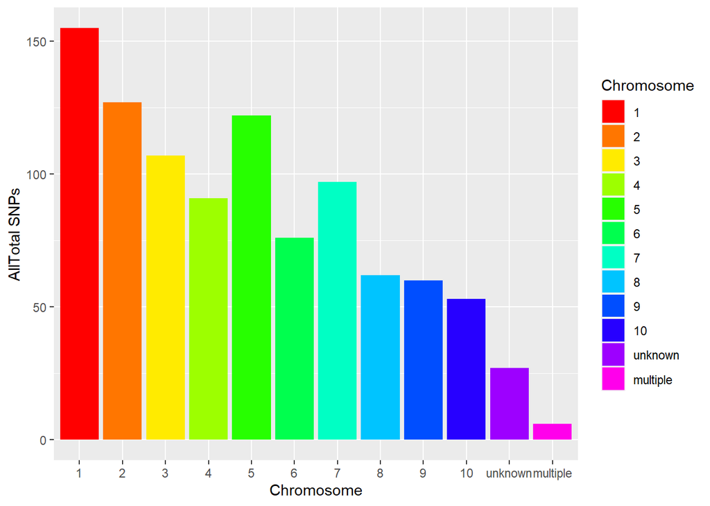

```r
cmergedfiles$Chromosome <- factor(cmergedfiles$Chromosome, levels = c("1", "2", "3", "4", "5", "6", "7", "8", "9", "10", "unknown", "multiple", "NA"))
ggplot(cmergedfiles) + geom_bar(aes(x = Chromosome, fill = Chromosome)) + scale_fill_manual(values = rainbow(length(levels(cmergedfiles$Chromosome)))) + xlab("Chromosome") + ylab("AllTotal SNPs")
```

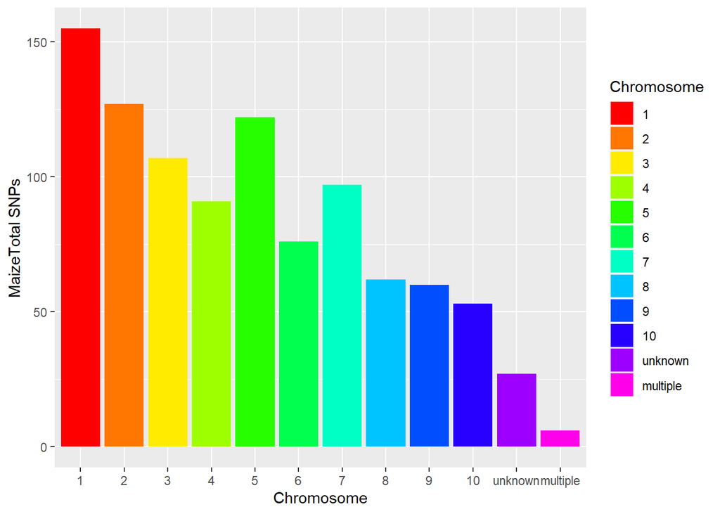

```r
mergedmaize$Chromosome <- factor(mergedmaize$Chromosome, levels = c("1", "2", "3", "4", "5", "6", "7", "8", "9", "10", "unknown", "multiple", "NA"))
ggplot(mergedmaize) + geom_bar(aes(x = Chromosome, fill = Chromosome)) + scale_fill_manual(values = rainbow(length(levels(mergedmaize$Chromosome)))) + xlab("Chromosome") + ylab("MaizeTotal SNPs")
```

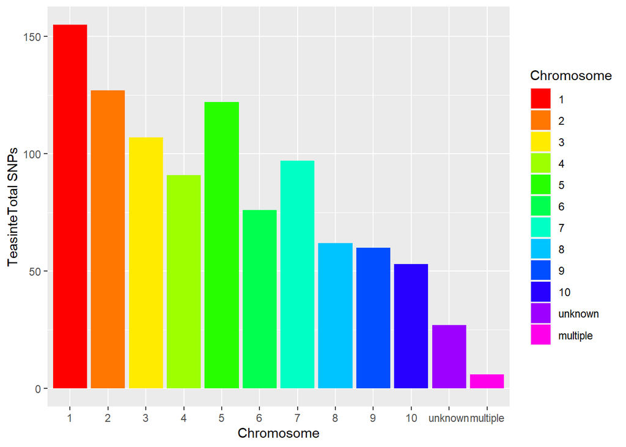

```r
mergedteosinte$Chromosome <- factor(mergedteosinte$Chromosome, levels = c("1", "2", "3", "4", "5", "6", "7", "8", "9", "10", "unknown", "multiple", "NA"))
ggplot(mergedteosinte) + geom_bar(aes(x = Chromosome, fill = Chromosome)) + scale_fill_manual(values = rainbow(length(levels(mergedteosinte$Chromosome)))) +
xlab("Chromosome") + ylab("TeasinteTotal SNPs")
```

Missing data and amount of heterozygosity visualization

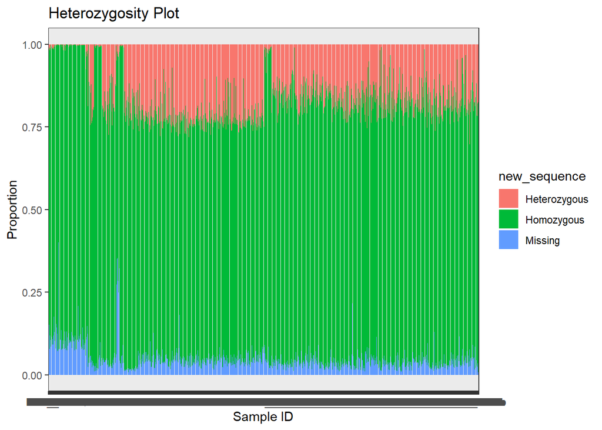

```r
moreinfogenotypes <- genotypes %>% select(-JG_OTU) %>% pivot_longer( -Sample_ID: -Group, names_to = "SNP_ID", values_to = "Sequence")
modifiedmoreinfogenotypes <- moreinfogenotypes %>% mutate(new_sequence = ifelse(Sequence %in% c("A/A", "T/T", "C/C", "G/G"), "Homozygous", ifelse(Sequence == "?/?", "Missing", "Heterozygous")))
view(modifiedmoreinfogenotypes)
ggplot(modifiedmoreinfogenotypes, aes(x = Sample_ID, fill = new_sequence)) + ggtitle("Heterozygosity Plot") + geom_bar(position = "fill") + theme_bw() + labs(x = "Sample ID", y = "Proportion")
```

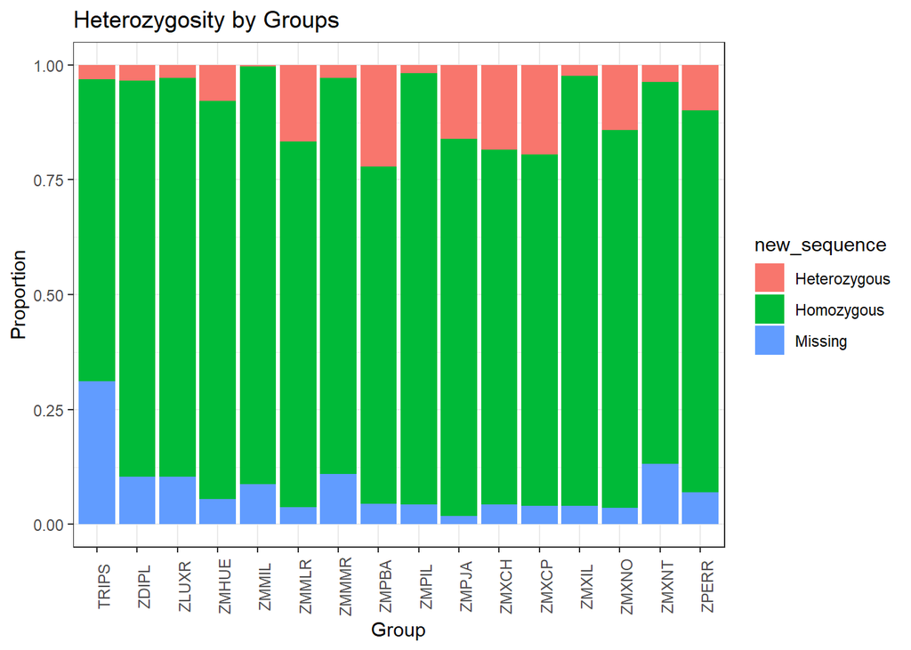

```r
ggplot(modifiedmoreinfogenotypes, aes(x = Group , fill = new_sequence)) + geom_bar(position = "fill") + ggtitle("Heterozygosity by Groups ") +  theme_bw() + theme(axis.text.x = element_text(angle = 90))+ labs(y = "Proportion")
```

My own visualization

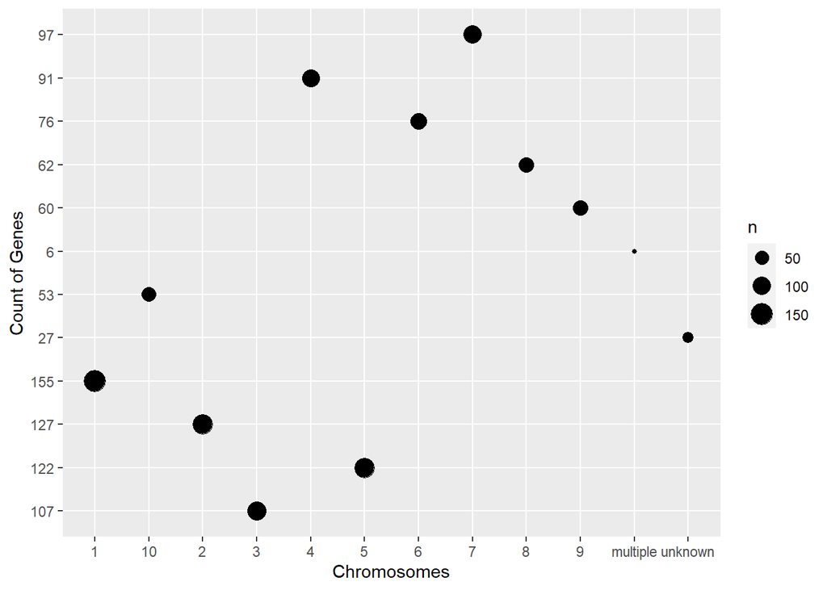

```r
mergedfiles <- transform(mergedfiles, gene_count = ave(Chromosome, Chromosome, FUN = length))


mergedfiles$gene <- factor(mergedfiles$gene)


ggplot(mergedfiles) +
  geom_count(aes(x = Chromosome, y = gene_count)) +
   xlab("Chromosomes") +
  ylab("Count of Genes")
```